# Risk Factor Analysis

## Outcome Variable

**Outcome Variable:** haz

## Predictor Variables

**Intervention Variable:** mwtkg

**Adjustment Set:**

unadjusted

## Stratifying Variables

The analysis was stratified on these variable(s):

- agecat
- studyid
- country

## Data Summary

| agecat | studyid | country | mwtkg | n_cell | n |
| --- | --- | --- | --- | --- | --- |
| Birth | MAL-ED | BANGLADESH | >=58 kg | 38 | 222 |
| Birth | MAL-ED | BANGLADESH | <52 kg | 143 | 222 |
| Birth | MAL-ED | BANGLADESH | [52-58) kg | 41 | 222 |
| Birth | MAL-ED | BRAZIL | >=58 kg | 34 | 64 |
| Birth | MAL-ED | BRAZIL | <52 kg | 15 | 64 |
| Birth | MAL-ED | BRAZIL | [52-58) kg | 15 | 64 |
| Birth | MAL-ED | INDIA | >=58 kg | 6 | 43 |
| Birth | MAL-ED | INDIA | <52 kg | 29 | 43 |
| Birth | MAL-ED | INDIA | [52-58) kg | 8 | 43 |
| Birth | MAL-ED | NEPAL | >=58 kg | 9 | 27 |
| Birth | MAL-ED | NEPAL | <52 kg | 8 | 27 |
| Birth | MAL-ED | NEPAL | [52-58) kg | 10 | 27 |
| Birth | MAL-ED | PERU | >=58 kg | 83 | 226 |
| Birth | MAL-ED | PERU | <52 kg | 84 | 226 |
| Birth | MAL-ED | PERU | [52-58) kg | 59 | 226 |
| Birth | MAL-ED | SOUTH AFRICA | >=58 kg | 69 | 101 |
| Birth | MAL-ED | SOUTH AFRICA | <52 kg | 10 | 101 |
| Birth | MAL-ED | SOUTH AFRICA | [52-58) kg | 22 | 101 |
| Birth | MAL-ED | TANZANIA, UNITED REPUBLIC OF | >=58 kg | 47 | 122 |
| Birth | MAL-ED | TANZANIA, UNITED REPUBLIC OF | <52 kg | 45 | 122 |
| Birth | MAL-ED | TANZANIA, UNITED REPUBLIC OF | [52-58) kg | 30 | 122 |
| Birth | NIH-Birth | BANGLADESH | >=58 kg | 80 | 608 |
| Birth | NIH-Birth | BANGLADESH | <52 kg | 441 | 608 |
| Birth | NIH-Birth | BANGLADESH | [52-58) kg | 87 | 608 |
| Birth | NIH-Crypto | BANGLADESH | >=58 kg | 186 | 729 |
| Birth | NIH-Crypto | BANGLADESH | <52 kg | 395 | 729 |
| Birth | NIH-Crypto | BANGLADESH | [52-58) kg | 148 | 729 |
| Birth | PROBIT | BELARUS | >=58 kg | 10277 | 13770 |
| Birth | PROBIT | BELARUS | <52 kg | 1131 | 13770 |
| Birth | PROBIT | BELARUS | [52-58) kg | 2362 | 13770 |

[output cut: 96 more lines]

The following strata were considered:

- agecat: 24 months, studyid: LCNI-5, country: MALAWI
- agecat: 24 months, studyid: MAL-ED, country: BANGLADESH
- agecat: 24 months, studyid: MAL-ED, country: BRAZIL
- agecat: 24 months, studyid: MAL-ED, country: INDIA
- agecat: 24 months, studyid: MAL-ED, country: NEPAL
- agecat: 24 months, studyid: MAL-ED, country: PERU
- agecat: 24 months, studyid: MAL-ED, country: SOUTH AFRICA
- agecat: 24 months, studyid: MAL-ED, country: TANZANIA, UNITED REPUBLIC OF
- agecat: 24 months, studyid: NIH-Birth, country: BANGLADESH
- agecat: 24 months, studyid: NIH-Crypto, country: BANGLADESH
- agecat: 24 months, studyid: PROBIT, country: BELARUS
- agecat: 24 months, studyid: PROVIDE, country: BANGLADESH
- agecat: 24 months, studyid: TanzaniaChild2, country: TANZANIA, UNITED REPUBLIC OF
- agecat: 24 months, studyid: ZVITAMBO, country: ZIMBABWE
- agecat: 6 months, studyid: LCNI-5, country: MALAWI
- agecat: 6 months, studyid: MAL-ED, country: BANGLADESH
- agecat: 6 months, studyid: MAL-ED, country: BRAZIL
- agecat: 6 months, studyid: MAL-ED, country: INDIA
- agecat: 6 months, studyid: MAL-ED, country: NEPAL
- agecat: 6 months, studyid: MAL-ED, country: PERU
- agecat: 6 months, studyid: MAL-ED, country: SOUTH AFRICA
- agecat: 6 months, studyid: MAL-ED, country: TANZANIA, UNITED REPUBLIC OF
- agecat: 6 months, studyid: NIH-Birth, country: BANGLADESH
- agecat: 6 months, studyid: NIH-Crypto, country: BANGLADESH
- agecat: 6 months, studyid: PROBIT, country: BELARUS
- agecat: 6 months, studyid: PROVIDE, country: BANGLADESH
- agecat: 6 months, studyid: SAS-CompFeed, country: INDIA
- agecat: 6 months, studyid: TanzaniaChild2, country: TANZANIA, UNITED REPUBLIC OF
- agecat: 6 months, studyid: ZVITAMBO, country: ZIMBABWE
- agecat: Birth, studyid: MAL-ED, country: BANGLADESH
- agecat: Birth, studyid: MAL-ED, country: BRAZIL
- agecat: Birth, studyid: MAL-ED, country: INDIA
- agecat: Birth, studyid: MAL-ED, country: NEPAL
- agecat: Birth, studyid: MAL-ED, country: PERU
- agecat: Birth, studyid: MAL-ED, country: SOUTH AFRICA
- agecat: Birth, studyid: MAL-ED, country: TANZANIA, UNITED REPUBLIC OF
- agecat: Birth, studyid: NIH-Birth, country: BANGLADESH
- agecat: Birth, studyid: NIH-Crypto, country: BANGLADESH
- agecat: Birth, studyid: PROBIT, country: BELARUS
- agecat: Birth, studyid: PROVIDE, country: BANGLADESH
- agecat: Birth, studyid: SAS-CompFeed, country: INDIA
- agecat: Birth, studyid: ZVITAMBO, country: ZIMBABWE

### Dropped Strata

Some strata were dropped due to rare outcomes:

- agecat: 24 months, studyid: TanzaniaChild2, country: TANZANIA, UNITED REPUBLIC OF

## Methods Detail

We’re interested in the causal parameters $E[Y_a]$ for all values of $a \in \mathcal{A}$. These parameters represent the mean outcome if, possibly contrary to fact, we intervened to set all units to have $A=a$. Under the randomization and positivity assumptions, these are identified by the statistical parameters $\psi_a=E_W[E_{Y|A,W}(Y|A=a,W)]$. In addition, we’re interested in the mean of $Y$, $E[Y]$ under no intervention (the observed mean). We will estimate these parameters by using SuperLearner to fit the relevant likelihood factors – $E_{Y|A,W}(Y|A=a,W)$ and $p(A=a|W)$, and then updating our likelihood fit using a joint TMLE.

For unadjusted analyses ($W=\{\}$), initial likelihoods were estimated using Lrnr_glm to estimate the simple $E(Y|A)$ and Lrnr_mean to estimate $p(A)$. For adjusted analyses, a small library containing Lrnr_glmnet, Lrnr_xgboost, and Lrnr_mean was used.

Having estimated these parameters, we will then use the delta method to estimate relative risks and attributable risks relative to a prespecified baseline level of $A$.

# Results Detail

## Results Plots

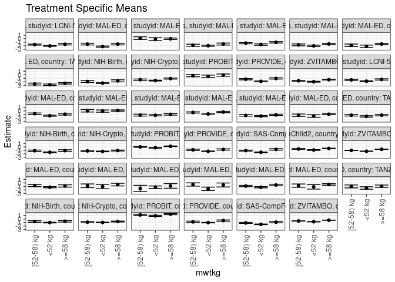

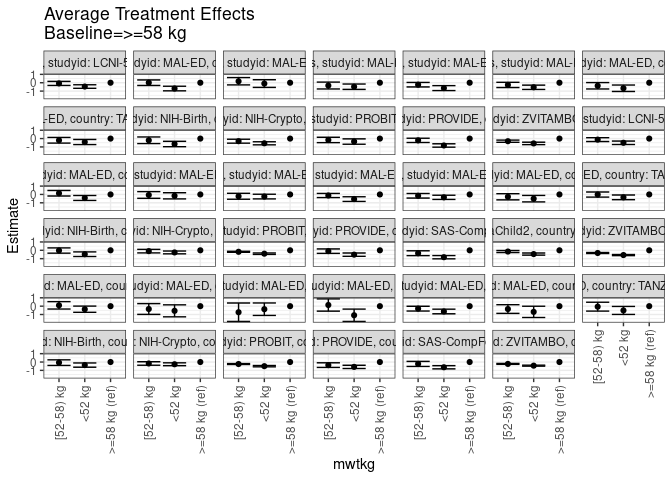

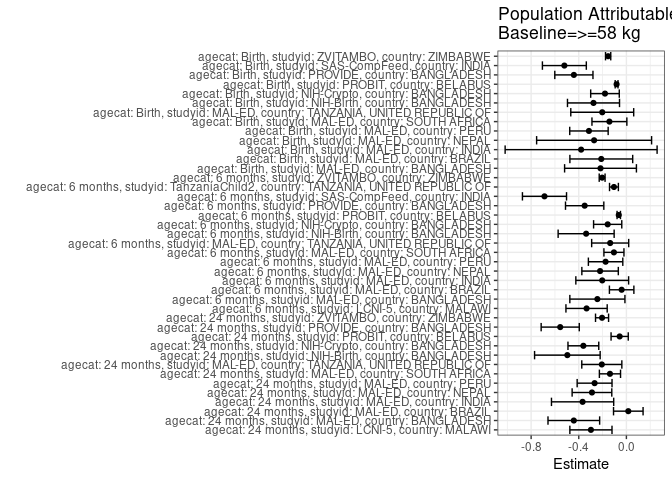

## Results Table

### Parameter: TSM

| agecat | studyid | country | intervention_level | baseline_level | estimate | ci_lower | ci_upper |
| --- | --- | --- | --- | --- | --- | --- | --- |
| Birth | MAL-ED | BANGLADESH | >=58 kg | NA | -0.8605263 | -1.1934296 | -0.5276230 |
| Birth | MAL-ED | BANGLADESH | <52 kg | NA | -1.2264336 | -1.3909880 | -1.0618791 |
| Birth | MAL-ED | BANGLADESH | [52-58) kg | NA | -0.7612195 | -1.0510261 | -0.4714129 |
| Birth | MAL-ED | BRAZIL | >=58 kg | NA | -0.4776471 | -0.8468523 | -0.1084419 |
| Birth | MAL-ED | BRAZIL | <52 kg | NA | -1.0366667 | -1.6510808 | -0.4222525 |
| Birth | MAL-ED | BRAZIL | [52-58) kg | NA | -0.8180000 | -1.3482352 | -0.2877648 |
| Birth | MAL-ED | INDIA | >=58 kg | NA | -0.8500000 | -1.5073907 | -0.1926093 |
| Birth | MAL-ED | INDIA | <52 kg | NA | -1.2131034 | -1.5635569 | -0.8626500 |
| Birth | MAL-ED | INDIA | [52-58) kg | NA | -1.5775000 | -2.4667124 | -0.6882876 |
| Birth | MAL-ED | NEPAL | >=58 kg | NA | -0.5822222 | -1.1447657 | -0.0196787 |
| Birth | MAL-ED | NEPAL | <52 kg | NA | -1.6712500 | -2.1476338 | -1.1948662 |
| Birth | MAL-ED | NEPAL | [52-58) kg | NA | -0.4430000 | -0.9133974 | 0.0273974 |
| Birth | MAL-ED | PERU | >=58 kg | NA | -0.5906024 | -0.8027164 | -0.3784884 |
| Birth | MAL-ED | PERU | <52 kg | NA | -1.2280952 | -1.4046435 | -1.0515470 |
| Birth | MAL-ED | PERU | [52-58) kg | NA | -0.8877966 | -1.0770202 | -0.6985731 |
| Birth | MAL-ED | SOUTH AFRICA | >=58 kg | NA | -0.4281159 | -0.6475624 | -0.2086694 |
| Birth | MAL-ED | SOUTH AFRICA | <52 kg | NA | -1.1110000 | -1.7501156 | -0.4718844 |
| Birth | MAL-ED | SOUTH AFRICA | [52-58) kg | NA | -0.7727273 | -1.2464289 | -0.2990256 |
| Birth | MAL-ED | TANZANIA, UNITED REPUBLIC OF | >=58 kg | NA | -0.9336170 | -1.2641440 | -0.6030901 |
| Birth | MAL-ED | TANZANIA, UNITED REPUBLIC OF | <52 kg | NA | -1.4435556 | -1.7889580 | -1.0981531 |
| Birth | MAL-ED | TANZANIA, UNITED REPUBLIC OF | [52-58) kg | NA | -0.9936667 | -1.4099926 | -0.5773408 |
| Birth | NIH-Birth | BANGLADESH | >=58 kg | NA | -0.6547500 | -0.8873394 | -0.4221606 |
| Birth | NIH-Birth | BANGLADESH | <52 kg | NA | -1.0210658 | -1.1242708 | -0.9178607 |
| Birth | NIH-Birth | BANGLADESH | [52-58) kg | NA | -0.7286207 | -0.9700029 | -0.4872385 |
| Birth | NIH-Crypto | BANGLADESH | >=58 kg | NA | -0.7291398 | -0.8667315 | -0.5915480 |
| Birth | NIH-Crypto | BANGLADESH | <52 kg | NA | -0.9954430 | -1.0937165 | -0.8971695 |
| Birth | NIH-Crypto | BANGLADESH | [52-58) kg | NA | -0.9039189 | -1.0604950 | -0.7473428 |
| Birth | PROBIT | BELARUS | >=58 kg | NA | 1.3940732 | 1.2326013 | 1.5555451 |
| Birth | PROBIT | BELARUS | <52 kg | NA | 0.8976702 | 0.7372930 | 1.0580474 |
| Birth | PROBIT | BELARUS | [52-58) kg | NA | 1.1520301 | 0.9944906 | 1.3095696 |

[output cut: 93 more lines]

### Parameter: E(Y)

| agecat | studyid | country | intervention_level | baseline_level | estimate | ci_lower | ci_upper |
| --- | --- | --- | --- | --- | --- | --- | --- |
| Birth | MAL-ED | BANGLADESH | NA | NA | -1.0778829 | -1.2122580 | -0.9435077 |
| Birth | MAL-ED | BRAZIL | NA | NA | -0.6884375 | -0.9678371 | -0.4090379 |
| Birth | MAL-ED | INDIA | NA | NA | -1.2302326 | -1.5393614 | -0.9211037 |
| Birth | MAL-ED | NEPAL | NA | NA | -0.8533333 | -1.2104864 | -0.4961803 |
| Birth | MAL-ED | PERU | NA | NA | -0.9051327 | -1.0238686 | -0.7863969 |
| Birth | MAL-ED | SOUTH AFRICA | NA | NA | -0.5707921 | -0.7685593 | -0.3730248 |
| Birth | MAL-ED | TANZANIA, UNITED REPUBLIC OF | NA | NA | -1.1364754 | -1.3478823 | -0.9250686 |
| Birth | NIH-Birth | BANGLADESH | NA | NA | -0.9310197 | -1.0197391 | -0.8423003 |
| Birth | NIH-Crypto | BANGLADESH | NA | NA | -0.9089163 | -0.9806324 | -0.8372002 |
| Birth | PROBIT | BELARUS | NA | NA | 1.3117829 | 1.1524074 | 1.4711583 |
| Birth | PROVIDE | BANGLADESH | NA | NA | -0.8925145 | -0.9687201 | -0.8163089 |
| Birth | SAS-CompFeed | INDIA | NA | NA | -1.4224372 | -1.5013447 | -1.3435298 |
| Birth | ZVITAMBO | ZIMBABWE | NA | NA | -0.4966839 | -0.5196015 | -0.4737663 |
| 6 months | LCNI-5 | MALAWI | NA | NA | -1.6584707 | -1.7281551 | -1.5887863 |
| 6 months | MAL-ED | BANGLADESH | NA | NA | -1.2049931 | -1.3222136 | -1.0877726 |
| 6 months | MAL-ED | BRAZIL | NA | NA | 0.0497516 | -0.0948051 | 0.1943083 |
| 6 months | MAL-ED | INDIA | NA | NA | -1.2059574 | -1.3243030 | -1.0876119 |
| 6 months | MAL-ED | NEPAL | NA | NA | -0.5615819 | -0.6741832 | -0.4489807 |
| 6 months | MAL-ED | PERU | NA | NA | -1.3241023 | -1.4325083 | -1.2156964 |
| 6 months | MAL-ED | SOUTH AFRICA | NA | NA | -1.0727443 | -1.2024880 | -0.9430006 |
| 6 months | MAL-ED | TANZANIA, UNITED REPUBLIC OF | NA | NA | -1.3687449 | -1.4907629 | -1.2467270 |
| 6 months | NIH-Birth | BANGLADESH | NA | NA | -1.4073821 | -1.4960598 | -1.3187043 |
| 6 months | NIH-Crypto | BANGLADESH | NA | NA | -1.1986783 | -1.2700937 | -1.1272630 |
| 6 months | PROBIT | BELARUS | NA | NA | 0.1064864 | 0.0157994 | 0.1971734 |
| 6 months | PROVIDE | BANGLADESH | NA | NA | -1.0895301 | -1.1639589 | -1.0151013 |
| 6 months | SAS-CompFeed | INDIA | NA | NA | -1.4006917 | -1.4821813 | -1.3192022 |
| 6 months | TanzaniaChild2 | TANZANIA, UNITED REPUBLIC OF | NA | NA | -0.5424765 | -0.5918460 | -0.4931071 |
| 6 months | ZVITAMBO | ZIMBABWE | NA | NA | -0.8785195 | -0.9045379 | -0.8525011 |
| 24 months | LCNI-5 | MALAWI | NA | NA | -1.8854671 | -1.9666281 | -1.8043062 |
| 24 months | MAL-ED | BANGLADESH | NA | NA | -1.9783962 | -2.1050210 | -1.8517715 |
| 24 months | MAL-ED | BRAZIL | NA | NA | 0.0059127 | -0.1637934 | 0.1756188 |
| 24 months | MAL-ED | INDIA | NA | NA | -1.8844690 | -2.0097879 | -1.7591502 |
| 24 months | MAL-ED | NEPAL | NA | NA | -1.3075877 | -1.4270718 | -1.1881037 |
| 24 months | MAL-ED | PERU | NA | NA | -1.7524710 | -1.8736426 | -1.6312994 |
| 24 months | MAL-ED | SOUTH AFRICA | NA | NA | -1.6432229 | -1.7795844 | -1.5068615 |
| 24 months | MAL-ED | TANZANIA, UNITED REPUBLIC OF | NA | NA | -2.6455607 | -2.7807256 | -2.5103959 |
| 24 months | NIH-Birth | BANGLADESH | NA | NA | -2.2190579 | -2.3217459 | -2.1163699 |
| 24 months | NIH-Crypto | BANGLADESH | NA | NA | -1.4412646 | -1.5249156 | -1.3576135 |
| 24 months | PROBIT | BELARUS | NA | NA | -0.1439152 | -0.4247957 | 0.1369654 |
| 24 months | PROVIDE | BANGLADESH | NA | NA | -1.6002600 | -1.6836163 | -1.5169036 |
| 24 months | ZVITAMBO | ZIMBABWE | NA | NA | -1.6070497 | -1.6645093 | -1.5495902 |

### Parameter: ATE

| agecat | studyid | country | intervention_level | baseline_level | estimate | ci_lower | ci_upper |
| --- | --- | --- | --- | --- | --- | --- | --- |
| Birth | MAL-ED | BANGLADESH | >=58 kg | >=58 kg | 0.0000000 | 0.0000000 | 0.0000000 |
| Birth | MAL-ED | BANGLADESH | <52 kg | >=58 kg | -0.3659073 | -0.7372599 | 0.0054454 |
| Birth | MAL-ED | BANGLADESH | [52-58) kg | >=58 kg | 0.0993068 | -0.3420688 | 0.5406824 |
| Birth | MAL-ED | BRAZIL | >=58 kg | >=58 kg | 0.0000000 | 0.0000000 | 0.0000000 |
| Birth | MAL-ED | BRAZIL | <52 kg | >=58 kg | -0.5590196 | -1.2758301 | 0.1577908 |
| Birth | MAL-ED | BRAZIL | [52-58) kg | >=58 kg | -0.3403529 | -0.9864658 | 0.3057600 |
| Birth | MAL-ED | INDIA | >=58 kg | >=58 kg | 0.0000000 | 0.0000000 | 0.0000000 |
| Birth | MAL-ED | INDIA | <52 kg | >=58 kg | -0.3631034 | -1.1080734 | 0.3818665 |
| Birth | MAL-ED | INDIA | [52-58) kg | >=58 kg | -0.7275000 | -1.8333306 | 0.3783306 |
| Birth | MAL-ED | NEPAL | >=58 kg | >=58 kg | 0.0000000 | 0.0000000 | 0.0000000 |
| Birth | MAL-ED | NEPAL | <52 kg | >=58 kg | -1.0890278 | -1.8261822 | -0.3518733 |
| Birth | MAL-ED | NEPAL | [52-58) kg | >=58 kg | 0.1392222 | -0.5940778 | 0.8725223 |
| Birth | MAL-ED | PERU | >=58 kg | >=58 kg | 0.0000000 | 0.0000000 | 0.0000000 |
| Birth | MAL-ED | PERU | <52 kg | >=58 kg | -0.6374928 | -0.9134668 | -0.3615188 |
| Birth | MAL-ED | PERU | [52-58) kg | >=58 kg | -0.2971942 | -0.5814439 | -0.0129445 |
| Birth | MAL-ED | SOUTH AFRICA | >=58 kg | >=58 kg | 0.0000000 | 0.0000000 | 0.0000000 |
| Birth | MAL-ED | SOUTH AFRICA | <52 kg | >=58 kg | -0.6828841 | -1.3586248 | -0.0071433 |
| Birth | MAL-ED | SOUTH AFRICA | [52-58) kg | >=58 kg | -0.3446113 | -0.8666746 | 0.1774519 |
| Birth | MAL-ED | TANZANIA, UNITED REPUBLIC OF | >=58 kg | >=58 kg | 0.0000000 | 0.0000000 | 0.0000000 |
| Birth | MAL-ED | TANZANIA, UNITED REPUBLIC OF | <52 kg | >=58 kg | -0.5099385 | -0.9880085 | -0.0318685 |
| Birth | MAL-ED | TANZANIA, UNITED REPUBLIC OF | [52-58) kg | >=58 kg | -0.0600496 | -0.5916278 | 0.4715285 |
| Birth | NIH-Birth | BANGLADESH | >=58 kg | >=58 kg | 0.0000000 | 0.0000000 | 0.0000000 |
| Birth | NIH-Birth | BANGLADESH | <52 kg | >=58 kg | -0.3663158 | -0.6207742 | -0.1118573 |
| Birth | NIH-Birth | BANGLADESH | [52-58) kg | >=58 kg | -0.0738707 | -0.4090769 | 0.2613355 |
| Birth | NIH-Crypto | BANGLADESH | >=58 kg | >=58 kg | 0.0000000 | 0.0000000 | 0.0000000 |
| Birth | NIH-Crypto | BANGLADESH | <52 kg | >=58 kg | -0.2663033 | -0.4353866 | -0.0972199 |
| Birth | NIH-Crypto | BANGLADESH | [52-58) kg | >=58 kg | -0.1747791 | -0.3832199 | 0.0336617 |
| Birth | PROBIT | BELARUS | >=58 kg | >=58 kg | 0.0000000 | 0.0000000 | 0.0000000 |
| Birth | PROBIT | BELARUS | <52 kg | >=58 kg | -0.4964030 | -0.5768313 | -0.4159747 |
| Birth | PROBIT | BELARUS | [52-58) kg | >=58 kg | -0.2420431 | -0.2984702 | -0.1856160 |

[output cut: 93 more lines]

### Parameter: PAR

| agecat | studyid | country | intervention_level | baseline_level | estimate | ci_lower | ci_upper |
| --- | --- | --- | --- | --- | --- | --- | --- |
| Birth | MAL-ED | BANGLADESH | >=58 kg | NA | -0.2173566 | -0.5189214 | 0.0842082 |
| Birth | MAL-ED | BRAZIL | >=58 kg | NA | -0.2107904 | -0.4745036 | 0.0529227 |
| Birth | MAL-ED | INDIA | >=58 kg | NA | -0.3802326 | -1.0182919 | 0.2578268 |
| Birth | MAL-ED | NEPAL | >=58 kg | NA | -0.2711111 | -0.7538568 | 0.2116346 |
| Birth | MAL-ED | PERU | >=58 kg | NA | -0.3145303 | -0.4759090 | -0.1531516 |
| Birth | MAL-ED | SOUTH AFRICA | >=58 kg | NA | -0.1426761 | -0.2892036 | 0.0038513 |
| Birth | MAL-ED | TANZANIA, UNITED REPUBLIC OF | >=58 kg | NA | -0.2028584 | -0.4669913 | 0.0612745 |
| Birth | NIH-Birth | BANGLADESH | >=58 kg | NA | -0.2762697 | -0.4947479 | -0.0577916 |
| Birth | NIH-Crypto | BANGLADESH | >=58 kg | NA | -0.1797765 | -0.2998356 | -0.0597175 |
| Birth | PROBIT | BELARUS | >=58 kg | NA | -0.0822903 | -0.0941277 | -0.0704529 |
| Birth | PROVIDE | BANGLADESH | >=58 kg | NA | -0.4409760 | -0.6012338 | -0.2807183 |
| Birth | SAS-CompFeed | INDIA | >=58 kg | NA | -0.5208817 | -0.7052514 | -0.3365120 |
| Birth | ZVITAMBO | ZIMBABWE | >=58 kg | NA | -0.1533506 | -0.1753006 | -0.1314005 |
| 6 months | LCNI-5 | MALAWI | >=58 kg | NA | -0.3344356 | -0.5076680 | -0.1612033 |
| 6 months | MAL-ED | BANGLADESH | >=58 kg | NA | -0.2436163 | -0.4748948 | -0.0123378 |
| 6 months | MAL-ED | BRAZIL | >=58 kg | NA | -0.0398834 | -0.1426181 | 0.0628512 |
| 6 months | MAL-ED | INDIA | >=58 kg | NA | -0.2029574 | -0.4245449 | 0.0186301 |
| 6 months | MAL-ED | NEPAL | >=58 kg | NA | -0.2209912 | -0.3740784 | -0.0679040 |
| 6 months | MAL-ED | PERU | >=58 kg | NA | -0.1747357 | -0.3192246 | -0.0302467 |
| 6 months | MAL-ED | SOUTH AFRICA | >=58 kg | NA | -0.1046624 | -0.1887827 | -0.0205421 |
| 6 months | MAL-ED | TANZANIA, UNITED REPUBLIC OF | >=58 kg | NA | -0.1361917 | -0.2916826 | 0.0192991 |
| 6 months | NIH-Birth | BANGLADESH | >=58 kg | NA | -0.3380745 | -0.5732423 | -0.1029068 |
| 6 months | NIH-Crypto | BANGLADESH | >=58 kg | NA | -0.1571838 | -0.2755019 | -0.0388656 |
| 6 months | PROBIT | BELARUS | >=58 kg | NA | -0.0640851 | -0.0783336 | -0.0498366 |
| 6 months | PROVIDE | BANGLADESH | >=58 kg | NA | -0.3504476 | -0.5113113 | -0.1895839 |
| 6 months | SAS-CompFeed | INDIA | >=58 kg | NA | -0.6878634 | -0.8729868 | -0.5027401 |
| 6 months | TanzaniaChild2 | TANZANIA, UNITED REPUBLIC OF | >=58 kg | NA | -0.1044659 | -0.1416126 | -0.0673193 |
| 6 months | ZVITAMBO | ZIMBABWE | >=58 kg | NA | -0.2036868 | -0.2282788 | -0.1790948 |
| 24 months | LCNI-5 | MALAWI | >=58 kg | NA | -0.2978048 | -0.4747492 | -0.1208603 |
| 24 months | MAL-ED | BANGLADESH | >=58 kg | NA | -0.4415212 | -0.6583750 | -0.2246675 |
| 24 months | MAL-ED | BRAZIL | >=58 kg | NA | 0.0160350 | -0.1080108 | 0.1400808 |
| 24 months | MAL-ED | INDIA | >=58 kg | NA | -0.3678901 | -0.6291634 | -0.1066168 |
| 24 months | MAL-ED | NEPAL | >=58 kg | NA | -0.2891667 | -0.4556721 | -0.1226612 |
| 24 months | MAL-ED | PERU | >=58 kg | NA | -0.2670814 | -0.4134722 | -0.1206905 |
| 24 months | MAL-ED | SOUTH AFRICA | >=58 kg | NA | -0.1379799 | -0.2268048 | -0.0491549 |
| 24 months | MAL-ED | TANZANIA, UNITED REPUBLIC OF | >=58 kg | NA | -0.2064754 | -0.3746829 | -0.0382678 |
| 24 months | NIH-Birth | BANGLADESH | >=58 kg | NA | -0.4957392 | -0.7710999 | -0.2203785 |
| 24 months | NIH-Crypto | BANGLADESH | >=58 kg | NA | -0.3613371 | -0.4905786 | -0.2320955 |
| 24 months | PROBIT | BELARUS | >=58 kg | NA | -0.0565306 | -0.1287078 | 0.0156466 |
| 24 months | PROVIDE | BANGLADESH | >=58 kg | NA | -0.5557555 | -0.7158161 | -0.3956948 |
| 24 months | ZVITAMBO | ZIMBABWE | >=58 kg | NA | -0.2044267 | -0.2592109 | -0.1496425 |